# Comparison between five different party

Tao Guo(tg2620)

Through out the whole history, the competition between the five groups have always been an topic. Let’s find out together what common and difference between all the precidents within each group by their Inauguration Speeches. We will consider throuth serval parts like Words Analysis, Sentences Analysis, Emotion Analysis and so on. By analysing the speeches between each party, maybe we can predict the tendency of potantial furture leading-party and the trend of what may interest people in the area of politics, economy and other scenarios. Now let’s go and find out with me!

Step-0

First,we should load the pakages what we may use for data mining and text processing. If there not packages in there we should load them as well as their dependencies.

```r
setwd("/Users/coco/Documents/GitHub/Spring2018-Project1-cocogt96/doc")
packages.used=c("rvest", "tibble", "qdap",
                "sentimentr", "gplots", "dplyr",
                "tm", "syuzhet", "factoextra",
                "beeswarm", "scales", "RColorBrewer",
                "RANN", "tm", "topicmodels")

# check packages that need to be installed.
packages.needed=setdiff(packages.used,
                        intersect(installed.packages()[,1],
                                  packages.used))
# install additional packages
if(length(packages.needed)>0){
  install.packages(packages.needed, dependencies = TRUE)
}

# load packages
library("rvest")
library("tibble")
# You may need to run
# sudo ln -f -s $(/usr/libexec/java_home)/jre/lib/server/libjvm.dylib /usr/local/lib
# in order to load qdap
library("sentimentr")
library("gplots")
library("dplyr")
library("tm")
library("syuzhet")
library("factoextra")
library("beeswarm")
library("scales")
library("RColorBrewer")
library("RANN")
library("tm")
library("topicmodels")
library("tidyr")
library("stringr")
library("readr")
library(qdap)
library(wordcloud)
library(RColorBrewer)
library(dplyr)
library(plyr)
library(tidytext)
library(ggplot2)
library(grid)
library(gridExtra)

library(dmm)
library(rJava)
source("../lib/plot.R")
```

Step-1

Managing the data in to some managable form. In order to do so, we should first read in both the InaugurationInfo and InauguationDates. And then combine them and drop extra redundancy data. After that we now have each row for each Inauguration speech which unique in $File or $President so that we read in each Inauguration speech as fulltext. So the final form all save in dataframe speeches.list has been done with the order of Capital letter of their presidents.

```r
info=read.csv("/Users/coco/Documents/GitHub/Spring2018-Project1-cocogt96/data/InaugurationInfo.csv", stringsAsFactors = FALSE)
date=read.table("/Users/coco/Documents/GitHub/Spring2018-Project1-cocogt96/data/InauguationDates.txt",fill=T,header = T,sep="\t")
folder.path="../data/InauguralSpeeches/"
speeches=list.files(path = folder.path, pattern = "*.txt")
index=order(info$President)
InaugurationInfo=info
for(i in 1:58){
  InaugurationInfo[i,]=info[index[i],]
}
date.thin=date%>%gather(speechterm,speechdate,'FIRST':'FOURTH')
Dt=date.thin[-which(date.thin$speechdate==""),]
index.inaugu=order(Dt$PRESIDENT)
Inaugutemp=Dt
for(i in 1:67){
  Inaugutemp[i,]=Dt[index.inaugu[i],]
}
Inaugutemp1=Inaugutemp
Inaugutemp1[31,]=Inaugutemp[32,]
Inaugutemp1[32,]=Inaugutemp[31,]
Inaugutemp1[21,]=Inaugutemp[23,]
Inaugutemp1[22,]=Inaugutemp[24,]
Inaugutemp1[23,]=Inaugutemp[21,]
Inaugutemp1[24,]=Inaugutemp[22,]
InauguationDates=Inaugutemp1[-c(5,10,11,25,29,42,44,46,53),]
speeches.list=cbind(InaugurationInfo,InauguationDates)
speeches.list=subset(speeches.list,select=-c(PRESIDENT,speechterm))
speeches.list$fulltext=NA
for(i in 1:58){
  filename=(paste0(folder.path,speeches[i]))
  text=read_file(filename)
  speeches.list$fulltext[i]=text
}
head(speeches.list,5)
```

|  | President | File | Term | Party | Words | speechdate | fulltext |
| --- | --- | --- | --- | --- | --- | --- | --- |
| 1 | Abraham Lincoln | AbrahamLincoln | 1 | Republican | 3637 | 3/4/1861 | Fellow-Citizens of the United States:In compliance with a custom as old as the Government itself, I appear before you to address you briefly and to take in your presence the oath prescribed by the Con… |
| 2 | Abraham Lincoln | AbrahamLincoln | 2 | Republican | 700 | 3/4/1865 | FELLOW-COUNTRYMEN: At this second appearing to take the oath of the Presidential office there is less occasion for an extended address than there was at the first. Then a statement somewhat in detail … |
| 3 | Andrew Jackson | AndrewJackson | 1 | Democratic | 1128 | 3/4/1829 | Fellow-Citizens:About to undertake the arduous duties that I have been appointed to perform by the choice of a free people, I avail myself of this customary and solemn occasion to express the gratitud… |
| 4 | Andrew Jackson | AndrewJackson | 2 | Democratic | 1176 | 3/4/1833 | Fellow-Citizens:The will of the American people, expressed through their unsolicited suffrages, calls me before you to pass through the solemnities preparatory to taking upon myself the duties of Pres… |
| 6 | Barack Obama | BarackObama | 1 | Democratic | 2395 | 1/20/2009 | My fellow citizens, I stand here today humbled by the task before us, grateful for the trust you have bestowed, mindful of the sacrifices borne by our ancestors. I thank President Bush for his service… |

Step-2 Sentences based Analysis

In order to analyse based on scentences, we split the fulltext in to scentences. So now we have a dataframe sentences.list each row corresponding to each scentence.

```r
sentences.list=NULL
sentences=NULL
for(i in 1:nrow(speeches.list)){
  sentences=sent_detect(speeches.list$fulltext[i],
                        endmarks = c("?", ".", "!", "|",";"))
  if(length(sentences)>0){
    emotions=get_nrc_sentiment(sentences)
    word.count=word_count(sentences)
    # colnames(emotions)=paste0("emo.", colnames(emotions))
    # in case the word counts are zeros?
    emotions=diag(1/(word.count+0.01))%*%as.matrix(emotions)
    sentences.list=rbind(sentences.list,
                        cbind(speeches.list[i,-ncol(speeches.list)],
                              sentences=as.character(sentences),
                              word.count,
                              emotions,
                              sent.id=1:length(sentences)
                              )
    )
  }
}
head(sentences.list,5)
```

|  | President | File | Term | Party | Words | speechdate | sentences | word.count | anger | anticipation | disgust | fear | joy | sadness | surprise | trust | negative | positive | sent.id |
| --- | --- | --- | --- | --- | --- | --- | --- | --- | --- | --- | --- | --- | --- | --- | --- | --- | --- | --- | --- |
| 1 | Abraham Lincoln | AbrahamLincoln | 1 | Republican | 3637 | 3/4/1861 | Fellow-Citizens of the United States:In compliance with a custom as old as the Government itself, I appear before you to address you briefly and to take in your presence the oath prescribed by the Con… | 54 | 0.01851509 | 0.00000000 | 0 | 0.03703018 | 0.00000000 | 0.01851509 | 0.00000000 | 0.11109054 | 0.03703018 | 0.11109054 | 1 |
| 2 | Abraham Lincoln | AbrahamLincoln | 1 | Republican | 3637 | 3/4/1861 | I do not consider it necessary at present for me to discuss those matters of administration about which there is no special anxiety or excitement. | 25 | 0.03998401 | 0.11995202 | 0 | 0.03998401 | 0.11995202 | 0.03998401 | 0.07996801 | 0.03998401 | 0.03998401 | 0.11995202 | 2 |
| 3 | Abraham Lincoln | AbrahamLincoln | 1 | Republican | 3637 | 3/4/1861 | Apprehension seems to exist among the people of the Southern States that by the accession of a Republican Administration their property and their peace and personal security are to be endangered. | 31 | 0.00000000 | 0.03224766 | 0 | 0.06449532 | 0.03224766 | 0.00000000 | 0.00000000 | 0.06449532 | 0.06449532 | 0.03224766 | 3 |
| 4 | Abraham Lincoln | AbrahamLincoln | 1 | Republican | 3637 | 3/4/1861 | There has never been any reasonable cause for such apprehension. | 10 | 0.00000000 | 0.00000000 | 0 | 0.09990010 | 0.00000000 | 0.00000000 | 0.00000000 | 0.00000000 | 0.09990010 | 0.00000000 | 4 |
| 5 | Abraham Lincoln | AbrahamLincoln | 1 | Republican | 3637 | 3/4/1861 | Indeed, the most ample evidence to the contrary has all the while existed and been open to their inspection. | 19 | 0.00000000 | 0.00000000 | 0 | 0.00000000 | 0.00000000 | 0.00000000 | 0.00000000 | 0.00000000 | 0.05260389 | 0.00000000 | 5 |

First, we consider the beeswarm plot for the whole data and group by the 5 seperate party. We can see from the plot that each party have similar min and max scentences length. However, we can see from the width of plot that the dominate precentage of Number of words in a sentence is between 0-40 for Republican and Democratic, while Fedralist and Whig seems evenly distriuted.

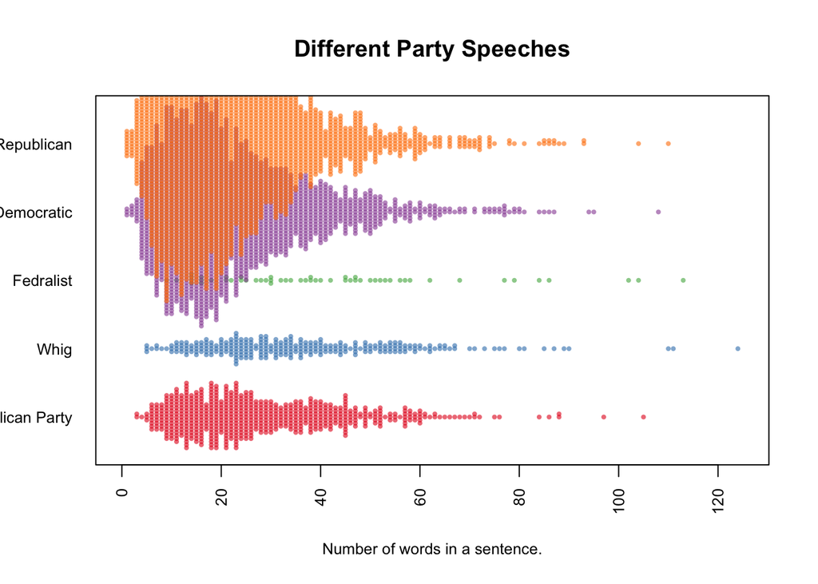

```r
#par(mar=c(4, 11, 2, 2))

#sel.comparison=levels(sentence.list$FileOrdered)

P=sentences.list
P$Party=factor(P$Party)
P$PartyOrdered=reorder(P$Party,P$word.count,mean,order = T)
beeswarm(word.count~PartyOrdered,
         data=P,
         horizontal = TRUE,
         pch=16, col=alpha(brewer.pal(9, "Set1"), 0.6),
         cex=0.55, cex.axis=0.8, cex.lab=0.8,
         spacing=3/nlevels(P$PartyOrdered),
         las=2, xlab="Number of words in a sentence.", ylab="",
         main="Different Party Speeches")
```

```r
par(mar=c(3, 6, 2, 1),mfrow=c(3,2))
for(i in na.omit(unique(sentences.list$Party))){
  Party.sep=filter(sentences.list, Party==i)
  Party.sep$File=factor(Party.sep$File)
  Party.sep$FileOrdered=reorder(Party.sep$File,
                                  Party.sep$word.count,
                                  mean,
                                  order=T)
beeswarm(word.count~FileOrdered,
         data=Party.sep,
         horizontal = TRUE,
         pch=16, col=alpha(brewer.pal(9, "Set1"), 0.6),
         cex=0.55, cex.axis=0.8, cex.lab=0.8,
         spacing=5/nlevels(Party.sep$FileOrdered),
         las=2, xlab="Number of words in a sentence.", ylab="",
         main=(paste0(i," Speeches")))
}
```

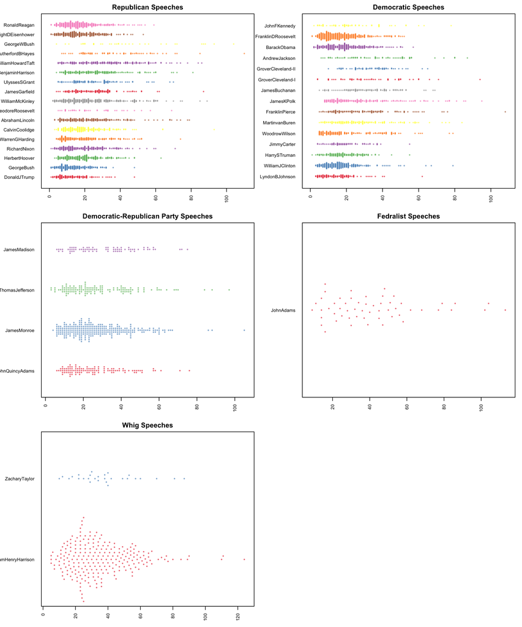

Step-3 Emotion based Analysis

First, we analyse the emotion chances based on scentences. To do that we find which scentence result in max value in 8 emotion: anger, anticipation, disgust, fear, joy, sadness, surprise, trust for seperate 5 party. For example, the most anger scentence for Democratic is “The Capital was abandoned.”. Also from this perspective we can conclude again how long scentences Fedralist perfer to use than the others.

```r
#find the max from anger to trust
for(i in na.omit(unique(sentences.list$Party))){
  cat("\n")
  print(i)

  s.d<-tbl_df(sentences.list)%>%filter(Party==i, word.count>=4)
  sentences.df=subset(s.d,select=c(sentences,anger:trust))
  sentences.df=as.data.frame(sentences.df)
  print(as.character(sentences.df$sentences[apply(sentences.df[,-1], 2, which.max)]))
}
```

```
##
## [1] "Republican"
## [1] "Whoever rejects it does of necessity fly to anarchy or to despotism."
## [2] "And God bless America."
## [3] "'May' Congress prohibit slavery in the Territories?"
## [4] "government is the problem."
## [5] "And God bless America."
## [6] "Dark pictures and gloomy forebodings are worse than useless."
## [7] "They have been magnificent."
## [8] "And God bless America."
##
## [1] "Democratic"
## [1] "The Capital was abandoned."
## [2] "We shall strive for perfection."
## [3] "With riches has come inexcusable waste."
```

[output cut: 35 more lines]

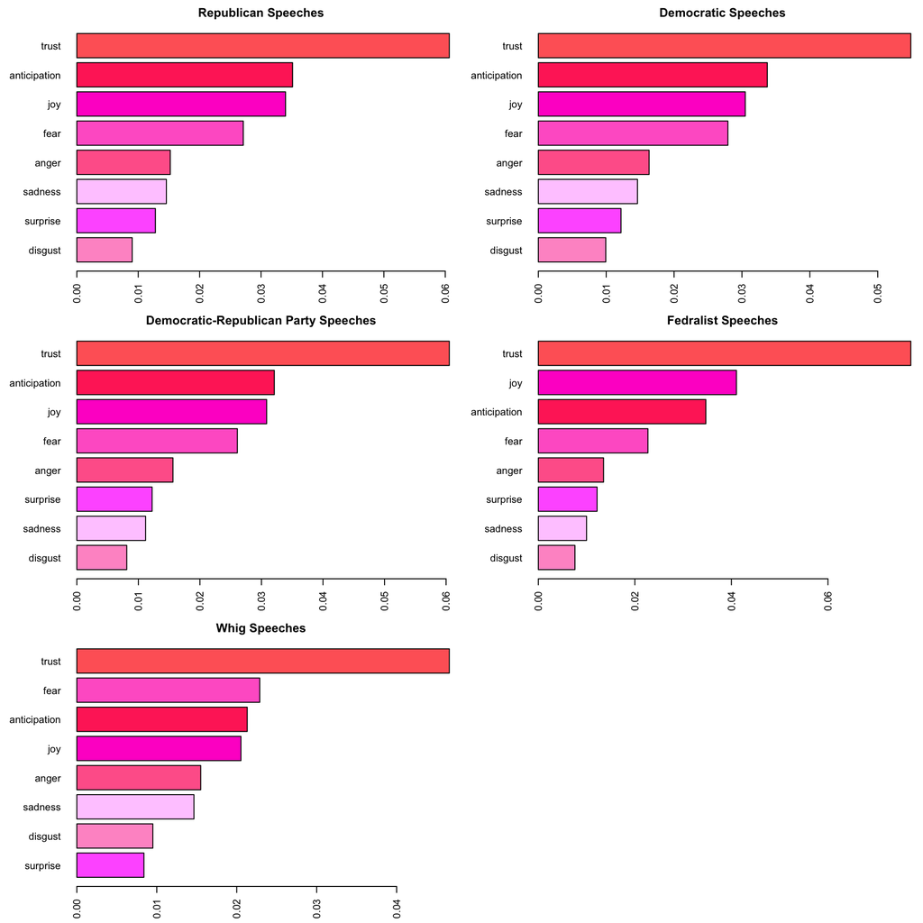

```r
par(mar=c(3, 6, 2, 1),mfrow=c(3,2))
for(i in na.omit(unique(sentences.list$Party))){
  e<-sentences.list%>%filter(Party==i)
  ee<-subset(e,select=anger:trust)
  emo.means=colMeans(ee,na.rm = T)
col.use=c("#FF6699", "#FF3366",
            "#FF99CC", "#FF66CC",
            "#FF33CC", "#FFCCFF",
            "#FF66FF", "#FF6666")
barplot(emo.means[order(emo.means)], las=2, col=col.use[order(emo.means)], horiz=T, main=paste0(i," Speeches"))
}
```

Step-4 Word and Topic based Analysis

To discover word frequency, we use wordcloud. First we clean the corpus of the data, remove the puctuation and stop words also transform all the upper case into small. From the Wordcloud below we can see that the most meaning noun are government, people, world, states. Some others likes peace freedom is also large enough. So we can conclude that the theme of the whole speeches through out the year is popular with these aspects.

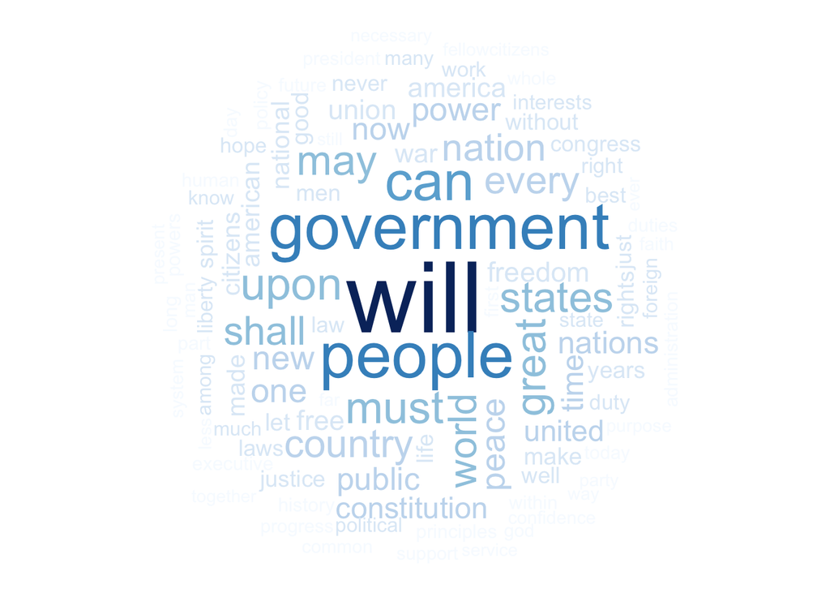

```r
ff.all<-Corpus(DirSource(folder.path))

ff.all<-tm_map(ff.all, stripWhitespace)
ff.all<-tm_map(ff.all, content_transformer(tolower))
ff.all<-tm_map(ff.all, removeWords, stopwords("english"))
ff.all<-tm_map(ff.all, removeWords, character(0))
ff.all<-tm_map(ff.all, removePunctuation)


tdm.all<-TermDocumentMatrix(ff.all)

tdm.tidy=tidy(tdm.all)
tdm.overall=summarise(group_by(tdm.tidy,term), sum(count))
abc<-aggregate(tdm.tidy$count,by=list(tdm.tidy$term),sum)
wordcloud(abc$Group.1, abc$x,
          scale=c(5,0.5),
          max.words=100,
          min.freq=1,
          random.order=FALSE,
          rot.per=0.3,
          use.r.layout=T,
          random.color=FALSE,
          colors=brewer.pal(9,"Blues"))
```

From the seperate wordcloud below we can see that different emphysis for different party. For example, for Democratic, we see some words like democracy, union texas some sort of words, these words may reveal their attitude towards the system and mechanism of this party as well as there amphythesis area of U.S., may be like Texas, for it appears many time. And other party can be derived in the same way.

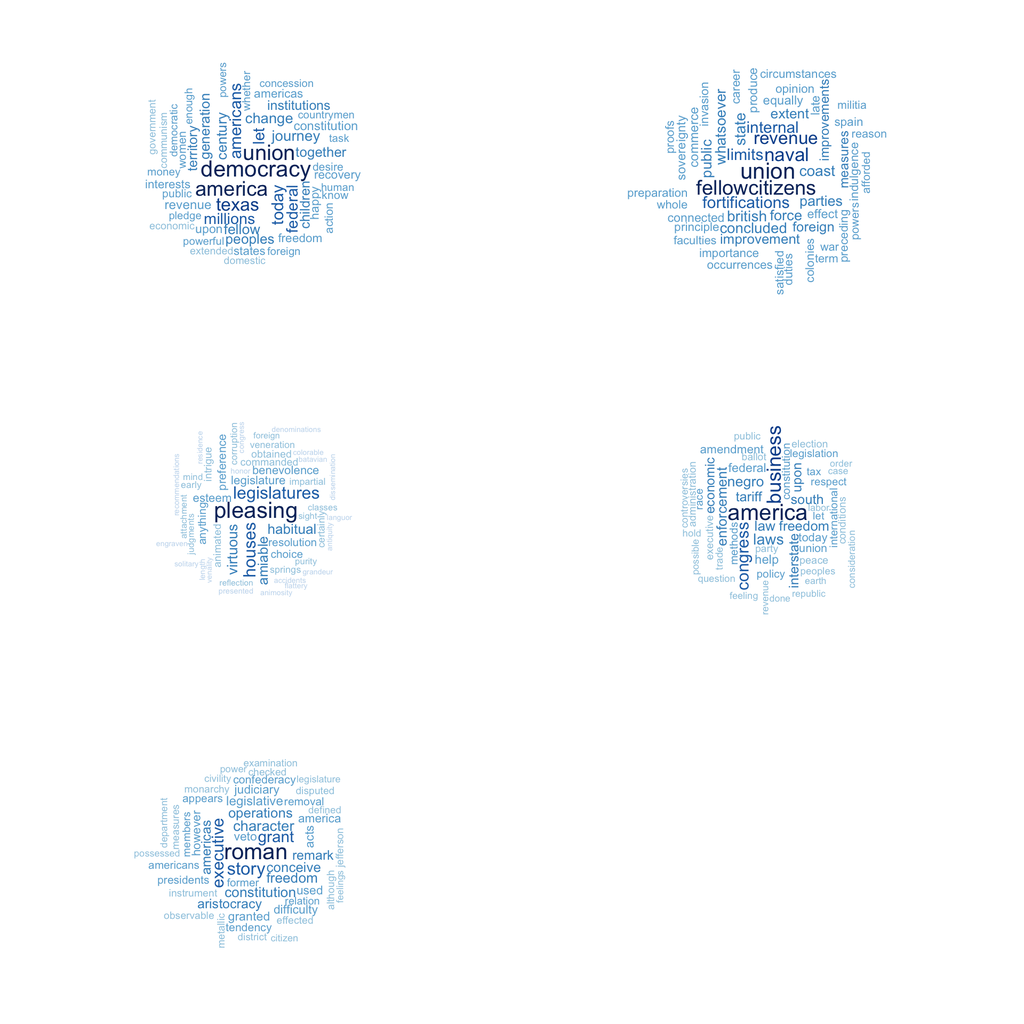

```r
dtm<-DocumentTermMatrix(ff.all,control = list(weighting =function(x) weightTfIdf(x,normalize = FALSE),stopwords=T))
ff.dtm=tidy(dtm)
Republican.Index=which(speeches.list$Party=="Republican")
Democratic.Index=which(speeches.list$Party=="Democratic")
DRP.Index=which(speeches.list$Party=="Democratic-Republican Party")
Fedralist.Index=which(speeches.list$Party=="Fedralist")
Whig.Index=which(speeches.list$Party=="Whig")
index.party=c(Republican.Index,Democratic.Index,DRP.Index,Fedralist.Index,Whig.Index)
mycompare<-function(x,Index){
  if(x %in% Index[1:24])
    return("R")
  else if(x %in% Index[25:46])
    return("D")
  else if(x %in% Index[47:53])
    return("DPR")
  else if(x %in% Index[54])
    return("F")
  else
    return("W")

}
ff.p<-unlist(lapply(ff.dtm$document,mycompare,index.party))
ff.ana<-cbind(ff.dtm,ff.p)
ff.split<-split(ff.ana,ff.p)
par(mar=c(2, 2, 2, 2),mfrow=c(3,2))
my.cloud<-function(ff.sep){
  fff<-aggregate(ff.sep$count,by=list(ff.sep$term),sum)
  wordcloud(fff$Group.1, fff$x,
            scale=c(2,0.1),
            max.words=50,
            min.freq=1,
            random.order=FALSE,
            rot.per=0.3,
            use.r.layout=T,
            random.color=FALSE,
            colors=brewer.pal(9,"Blues"))
}
sapply(ff.split,my.cloud)
```

This plot below shows the if-idf value of each term of each party. From these plot we can see clearly about the frequency of each word in different party. For Democratic is Texas, compromised and wished. For Fedralist is pleasing, houses and legislatures. For Whig is roman, story and grant. For Democratic-republican is colonies, occurrences and preceding. For Republican is interstate, negro and breeze. From these high frequency words we can conclude that each party have its own theme or emphysis. So it is worth topic-modeling for further search.

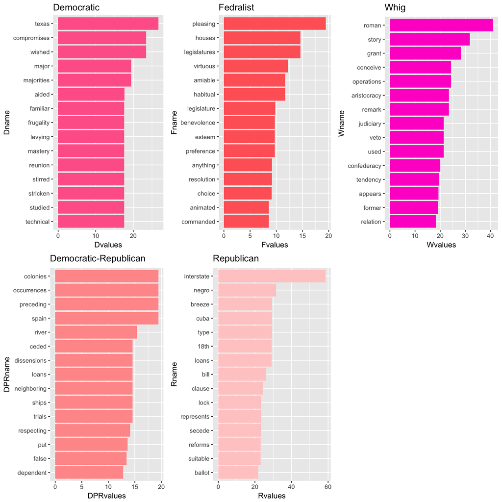

```r
mymean<-function(df){
  tapply(df$count,df$term,mean)
}
wordbyparty<-sapply(ff.split,mymean)
Dwords<-sort(wordbyparty$D,decreasing = T)
DPRwords<-sort(wordbyparty$DPR,decreasing = T)
Fwords<-sort(wordbyparty$F,decreasing = T)
Rwords<-sort(wordbyparty$R,decreasing = T)
Wwords<-sort(wordbyparty$W,decreasing = T)

Dname<-names(Dwords[1:15])
Dvalues<-as.vector(Dwords[1:15])
D<-data.frame(Dname,Dvalues)
D$Dname<-factor(D$Dname,levels =D$Dname[15:1])
plotD<-ggplot(data = D,aes(x=Dname,y=Dvalues))+geom_bar(stat = "identity",fill="#FF6699")+
  labs(title="Democratic")+
  coord_flip()

DPRname<-names(DPRwords[1:15])
DPRvalues<-as.vector(DPRwords[1:15])
DPR<-data.frame(DPRname,DPRvalues)
DPR$DPRname<-factor(DPR$DPRname,levels =DPR$DPRname[15:1])
plotDPR<-ggplot(data = DPR,aes(x=DPRname,y=DPRvalues))+geom_bar(stat = "identity",fill="#FF9999")+
  labs(title="Democratic-Republican")+
  coord_flip()

Fname<-names(Fwords[1:15])
Fvalues<-as.vector(Fwords[1:15])
F<-data.frame(Fname,Fvalues)
F$Fname<-factor(F$Fname,levels =F$Fname[15:1])
plotF<-ggplot(data = F,aes(x=Fname,y=Fvalues))+geom_bar(stat = "identity",fill="#FF6666")+
  labs(title="Fedralist")+
  coord_flip()

Rname<-names(Rwords[1:15])
Rvalues<-as.vector(Rwords[1:15])
R<-data.frame(Rname,Rvalues)
R$Rname<-factor(R$Rname,levels =R$Rname[15:1])
plotR<-ggplot(data = R,aes(x=Rname,y=Rvalues))+geom_bar(stat = "identity",fill="#FFCCCC")+
  labs(title="Republican")+
  coord_flip()

Wname<-names(Wwords[1:15])
Wvalues<-as.vector(Wwords[1:15])
W<-data.frame(Wname,Rvalues)
W$Wname<-factor(W$Wname,levels =W$Wname[15:1])
plotW<-ggplot(data = W,aes(x=Wname,y=Wvalues))+geom_bar(stat = "identity",fill="#FF33CC")+
  labs(title="Whig")+
  coord_flip()



multiplot(plotD,plotDPR,plotF,plotR,plotW,cols=3)
```

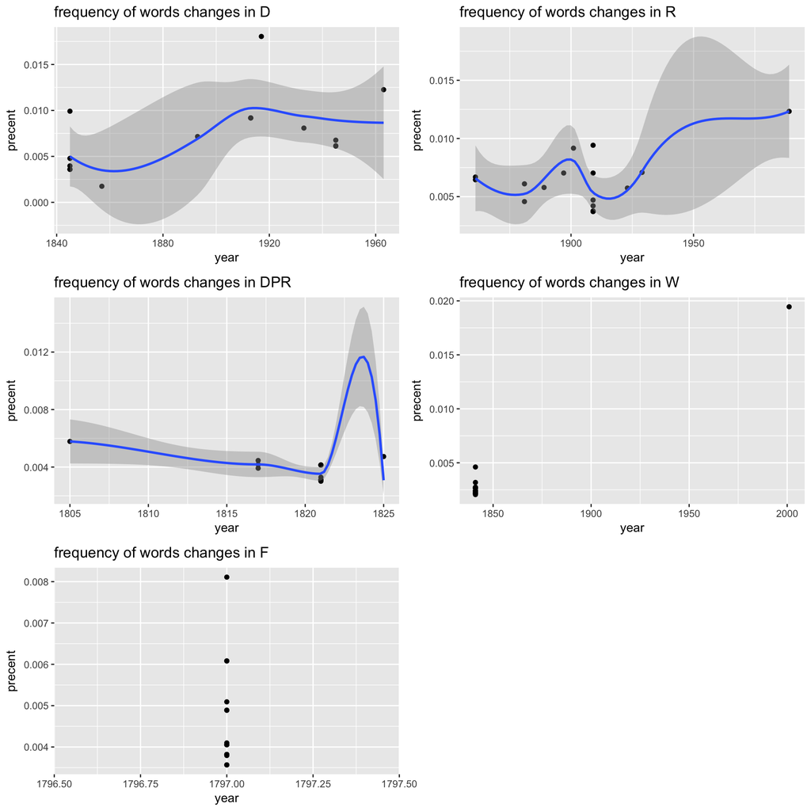

```r
dateformat<-as.Date(speeches.list$speechdate,format='%m/%d/%Y')
index.date<-order(dateformat)
ff.time<-seq()
class(ff.time)<-"Date"
for(i in as.numeric(ff.ana$document)){
  ff.time<-c(ff.time,dateformat[i])
}
ff.time=ff.time[-1]
ff.final<-cbind(ff.ana,ff.time)
ff.D<-ff.final[ff.final$ff.p=="D",]
ff.year<-substr(ff.final$ff.time,1,4)
ff.finall<-cbind(ff.final,ff.year)


ggD<-DrawTrend(ff.finall,"D")
ggDPR<-DrawTrend(ff.finall,"DPR")
ggF<-DrawTrend(ff.finall,"F")
ggR<-DrawTrend(ff.finall,"R")
ggW<-DrawTrend(ff.finall,"W")
multiplot(ggD,ggDPR,ggF,ggR,ggW,cols=2)
```

Conclusion:

We can analyse and compare the common and difference between different party.They all have their own charactics as well as same goal with each other. They all try to make U.S. a better country although with different methods and belief. Democratic and Republican can still be two dominate party in the area of politics in the society of the U.S.